# Supervised Machine Learning Models - GBM and Deep Learning

## Understanding the data

The data set available to us consists of 80,000 rows of loan default data. The variable can be bucketed into types such as:

- Applicant data: Age, education, os_type and so on
- Credit data: credit checks, credict card limit, debit card score and so on.
- Call data: calls made, service calls, high risk calls and so on.
- Loan data: loan term, loan amount, and so on.

We go through the following steps to clean the data:

1. Rename columns into more understandble and typical terms
2. Removing unnecessary, repititve columns
3. Fixing data types by converting categorical data from int64 to categoricals
4. Creating new features for missing data, missing phone activity and mismatch between application location and IP location
5. Changing system-based error values like -1, NAs, 99, 999 to 0
6. Binning continuous variables like loan term, loan amount, age, years of active phone usage.
7. Cleaning up category variables to include top levels and binning others in other.

```python
import pandas as pd
import numpy as np
import seaborn as sns
import matplotlib.pyplot as plt
import re

%matplotlib inline
```

```python
data = pd.read_csv('loan_default.csv')
```

```python
#renaming columns to more readable ones
oldnames = data.columns.tolist()
newnames = ["X", "unnamed", "id", "loan_default", "age_yr", "gender", "education", "loan_term", "date_applied", "OS_type", "app_city_level",
               "ip_appl_mismatch", "ap009", "cq_p2p_7d", "cq_sl_7d", "cq_p2p_1m", "cq_sl_1m", "cq_p2p_3m", "cq_sl_3m", "cq_p2p_6m", "cq_sl_6m", "cq_bank_6m",
               "count_hit_r6", "count_hit_r7", "count_hit_r8", "td025", "td026", "td027", "td028", "td029", "td044", "td048", "td051",
                "td054", "td055", "td061", "td062", "cq_time_1m", "cq_time_2m", "t_loan_amount", "cc_flag_8", "cc_mob_max_m", "dc_amount_score",
               "dc_utility_score", "dc_limit_score", "days_app_fhr", "days_app_fcc", "avg_len_chr_call", "avg_len_chr_call_in",
               "avg_len_chr_call_out", "avg_len_c_call","total_in_call_1m", "total_out_call_3m", "family_in_call_3m", "family_out_call_3m",
               "count_col_call_3m", "count_abnormal_call_2m", "count_abnormal_in_call_2m", "count_abnormal_call_3m", "count_abnormal_in_call_3m", "count_abnormal_out_call_3m",
               "count_abcall_day_2m", "count_abcall_day_3m", "distinct_call_1m", "distinct_out_call_1m", "distinct_call_2m", "distinct_out_call_2m", "distinct_call_3m", "distinct_out_call_3m",
               "freqout_in_call_2m", "freqin_out_call_2m", "freqout_out_call_2m", "freqin_in_call_2m", "freqout_in_call_3m", "freqin_out_call_3m", "freqout_out_call_3m", "len_freqout_out_call_3m", "len_freqin_in_call_3m",
               "count_service_out_call_2m", "count_service_call_3m", "count_service_out_call_3m", "len_service_call_1m", "len_service_out_call_1m", "len_service_call_2m", "len_service_out_call_2m",
               "len_service_call_3m", "len_service_out_call_3m", "years_phone_active", "mob_brand"]

data.rename(columns = {oldnames[i] : newnames[i] for i in range(len(oldnames))}, errors = 'raise', inplace = True)

#removing date and additional id columns
a = list(range(2,89))
a.remove(8)
data = data.iloc[:, a]
data.head()

#creating new dataset with fixed types
data1 = data.copy()
#data1.info()
```

```python
def data_clean(data1):
    #Fixing the following datatypes to factors
    data1['loan_default'] = data1['loan_default'].astype('object')
    data1['gender'] = data1['gender'].astype(str)
    data1['loan_term'] = data1['loan_term'].astype(str)
    data1['education'] = data1['education'].astype(str)
    data1['OS_type'] = data1['OS_type'].astype(str)
    data1['app_city_level'] = data1['app_city_level'].astype(str)
    data1['ip_appl_mismatch'] = data1['ip_appl_mismatch'].astype(str)
    data1['ap009'] = data1['ap009'].astype(str)
    data1['mob_brand'] = data1['mob_brand'].astype(str)
    #creating a new variable mismatch to see if there is a mismatch between the level of the ip address and the application city
    data1['mismatch'] = np.where(data1['app_city_level'] == data1['ip_appl_mismatch'], 1, 0)
    #dropping columns which do not add any value based on earlier EDA
    #drop_cols = ["td025", "td026", "td027", "td028", "td029", "td044", "td048", "td051", "td054", "td055", "td061", "td062", "cc_flag_8", "cq_sl_1m","cq_p2p_3m", "cq_sl_3m"]
    #data1.drop(drop_cols, axis = 1, inplace = True)
    #replacing categories in mobile brands
    data1['mob_brand'] = data1['mob_brand'].str.replace("IPHONE\\d", 'Iphone') #cleaning up iphone levels
    data1['mob_brand'] = data1['mob_brand'].str.replace("IPAD\\d", 'Iphone') #cleaning up iphone levels
    data1['mob_brand'] = data1['mob_brand'].str.lower() #converting all brands to lower
    other_brands = pd.Series(["web", "iphone", "oppo", "noinfo", "vivo", "huawei", "samsung", "xiaomi", "honor", "meizu",
                "gionee", "leeco", "letv", "360", "coolpad"]) #creating top 15 brands
    data1['mob_brand'] = data1['mob_brand'].apply(lambda x: x if any([k == x for k in other_brands]) else 'other') #rebucketing all other brands
    #creating a new variable phone missing for missing active phone yeards data
    data1['phone_missing'] = data1['years_phone_active'].apply(lambda x: 1 if np.isnan(x) else 0)
    #creating new variables for rows with missing data
    data1['nodata_1'] = data1['total_in_call_1m'].apply(lambda x: 1 if np.isnan(x) else 0)
    data1['nodata_2'] = data1['count_hit_r6'].apply(lambda x: 1 if np.isnan(x) else 0)
    check_cols = data1.isin([-98, -99, -1]).sum().sort_values(ascending = False)
    check_cols = check_cols[check_cols > 0]
    check_cols = check_cols.index
    for col in check_cols:
        try:
            check_rows = data[data[col].isin([-99, -98, -1])].index
            data1.iloc[check_rows, col] = np.nan
        except:
            continue
    #Creating index of columns with null values
    null_col = data1.isnull().sum().sort_values(ascending = False)
    null_col = null_col[ null_col > 0]
    #Looping through to replace NAs with mean values
    null_col = null_col.index
    for col in null_col:
        data1.loc[:, col].fillna(data1.loc[:, col].median(), inplace = True)
    return data1

def train_binning(data1):
    #binning age, phone usage and loan term data and creating bins for use in next function
    data1['age_yr_bin'], year_bin = pd.qcut(data1['age_yr'], q = 10, precision = 0, retbins= True)
    year_bin = np.concatenate(([-np.inf], year_bin[1:-1], [np.inf]))
    data1['t_loan_amount_bin'], loan_bin = pd.qcut(data1['t_loan_amount'], q = 5, precision = 0, retbins = True)
    loan_bin = np.concatenate(([-np.inf], loan_bin[1:-1], [np.inf]))
    data1['distinct_call_3m_bins'], dc3m_bin = pd.qcut(data1['distinct_call_3m'], q = 5, precision = 0, retbins = True)
    dc3m_bin = np.concatenate(([-np.inf], dc3m_bin[1:-1], [np.inf]))
    data1['years_phone_active_bins'], phone_bin = pd.qcut(data1['years_phone_active'], q = 5, precision = 0, retbins = True)
    phone_bin = np.concatenate(([-np.inf], phone_bin[1:-1], [np.inf]))
    data1['total_in_call_1m_bins'], tic1_bin = pd.qcut(data1['total_in_call_1m'], q = 5, precision = 0, retbins = True)
    tic1_bin = np.concatenate(([-np.inf], tic1_bin[1:-1], [np.inf]))
    data1['len_service_out_call_1m_bins'], lsoc1_bin = pd.qcut(data1['len_service_out_call_1m'], q = 5, precision = 0, retbins = True)
    lsoc1_bin = np.concatenate(([-np.inf], lsoc1_bin[1:-1], [np.inf]))
    data1['cq_sl_7d_bins'], cqls7_bin = pd.qcut(data1['cq_sl_7d'], q = 5, duplicates = 'drop', precision = 0, retbins = True)
    cqls7_bin = np.concatenate(([-np.inf], cqls7_bin[1:-1], [np.inf]))
    data1['len_service_out_call_2m_bins'], lsoc2_bin = pd.qcut(data1['len_service_out_call_2m'], q = 5, precision = 0, retbins = True)
    lsoc2_bin = np.concatenate(([-np.inf], lsoc2_bin[1:-1], [np.inf]))
    data1.drop(['age_yr', 't_loan_amount', 'years_phone_active', "cq_sl_1m", 'cq_p2p_1m', 'count_hit_r6', "cq_p2p_3m", "cq_sl_3m", "cq_p2p_6m", "cq_sl_6m", "cq_bank_6m", "cq_time_2m", "count_abnormal_call_3m",
                "dc_utility_score", "dc_limit_score", "days_app_fcc", "avg_len_chr_call", "avg_len_chr_call_in", "count_abnormal_in_call_3m", "count_abnormal_out_call_3m",
                "count_abcall_day_2m", "count_abcall_day_3m", "freqin_out_call_3m", "freqout_out_call_3m", "distinct_call_1m", "distinct_out_call_1m", "distinct_call_2m",
                "distinct_call_3m", 'len_service_out_call_1m', 'total_in_call_1m', 'cq_sl_7d', 'len_service_out_call_2m', 'avg_len_c_call', 'total_out_call_3m', 'family_in_call_3m',
                'family_out_call_3m', 'count_col_call_3m', 'freqout_in_call_2m', 'freqout_out_call_2m', 'freqin_out_call_2m', 'len_service_call_2m', 'len_service_out_call_3m',
                "len_freqout_out_call_3m", "len_freqin_in_call_3m", "count_service_out_call_2m", "count_service_call_3m", "count_service_out_call_3m", 'nodata_2',
                'count_abnormal_call_2m', 'distinct_out_call_2m', 'freqout_in_call_3m',
                "len_service_call_1m"], axis = 1, inplace = True) #remove high correlation variables
    return data1, year_bin, loan_bin, phone_bin, dc3m_bin, tic1_bin, lsoc1_bin, cqls7_bin, lsoc2_bin

def test_binning(data1, year_bin, loan_bin, phone_bin, dc3m_bin, tic1_bin, lsoc1_bin, cqls7_bin, lsoc2_bin):
    data1['age_yr_bin'] = pd.cut(data1['age_yr'], year_bin)
    data1['t_loan_amount_bin'] = pd.cut(data1['t_loan_amount'], loan_bin)
    data1['years_phone_active_bins'] = pd.cut(data1['years_phone_active'], phone_bin)
    data1['distinct_call_3m_bins'] = pd.cut(data1['distinct_call_3m'], dc3m_bin)
    data1['total_in_call_1m_bins'] = pd.cut(data1['total_in_call_1m'], tic1_bin)
    data1['len_service_out_call_1m_bins'] = pd.cut(data1['len_service_out_call_1m'], lsoc1_bin)
    data1['cq_sl_7d_bins'] = pd.cut(data1['cq_sl_7d'], cqls7_bin)
    data1['len_service_out_call_2m_bins'] = pd.cut(data1['len_service_out_call_2m'], lsoc2_bin)
    data1.drop(['age_yr', 't_loan_amount', 'years_phone_active', "cq_sl_1m", 'cq_p2p_1m', 'count_hit_r6', "cq_p2p_3m", "cq_sl_3m", "cq_p2p_6m", "cq_sl_6m", "cq_bank_6m", "cq_time_2m", "count_abnormal_call_3m",
                "dc_utility_score", "dc_limit_score", "days_app_fcc", "avg_len_chr_call", "avg_len_chr_call_in", "count_abnormal_in_call_3m", "count_abnormal_out_call_3m",
                "count_abcall_day_2m", "count_abcall_day_3m", "freqin_out_call_3m", "freqout_out_call_3m", "distinct_call_1m", "distinct_out_call_1m", "distinct_call_2m",
                "distinct_call_3m", 'len_service_out_call_1m', 'total_in_call_1m', 'cq_sl_7d', 'len_service_out_call_2m', 'avg_len_c_call', 'total_out_call_3m', 'family_in_call_3m',
                'family_out_call_3m', 'count_col_call_3m', 'freqout_in_call_2m', 'freqout_out_call_2m', 'freqin_out_call_2m', 'len_service_call_2m', 'len_service_out_call_3m',
                "len_freqout_out_call_3m", "len_freqin_in_call_3m", "count_service_out_call_2m", "count_service_call_3m", "count_service_out_call_3m", 'nodata_2',
                'count_abnormal_call_2m', 'distinct_out_call_2m', 'freqout_in_call_3m',
                "len_service_call_1m"], axis = 1, inplace = True)
    return data1

# 'cq_time_1m', 't_loan_amount_bin', 'count_abnormal_call_2m', 'family_in_call_3m', 'total_out_call_3m', 'count_hit_r7', 'freqout_in_call_3m', 'family_out_call_3m',
 #   'len_service_call_3m', 'count_abnormal_in_call_2m', 'len_service_out_call_3m', 'freqin_in_call_2m'
```

## Setting up train and test sets for modeling

We use scikit learns train_test_split function to create train and test datasets for modelling.

We also use the functions built in the previous section to clean the dataset and build and include only required features, and to build a list of the predictor columns and set the target to loan default.

```python
#Creating train and test datasets
from sklearn.model_selection import train_test_split

train, test = train_test_split(data1,test_size=0.2, random_state = 257)
```

```python
%%capture [--no-stderr]

train = data_clean(train)
test = data_clean(test)
train, t_year_bin, t_loan_bin, t_phone_bin, t_dc3m_bin, t_tic1_bin, t_lsoc1_bin, t_cqls7_bin, t_lsoc2_bin = train_binning(train)
test = test_binning(test, t_year_bin, t_loan_bin, t_phone_bin, t_dc3m_bin, t_tic1_bin, t_lsoc1_bin, t_cqls7_bin, t_lsoc2_bin)
```

```python
target = 'loan_default'
predictors = train.columns.tolist()
predictors.remove('loan_default')
predictors.remove('id')
```

Now that we have 80% of the data in train and 20% in test, we will initiate h2o clusters and setup functions required for creating our classification model using the Gradient Boosting algorithm.

## Setting up the algorithm

We set up the algorithm through the following steps:

- Initiate h2o clusters
- create a function to identify important variables
- create a function to build a gains table
- create a function to plot AUC and precision curves

We also create a sample dataset with 10% of the data and run the GradientBoostingEstimator and functions to check if they work properly

```python
import h2o
h2o.init(max_mem_size="8G")
```

```
Checking whether there is an H2O instance running at http://localhost:54321 . connected.
```

| H2O_cluster_uptime: | 1 hour 1 min |
| --- | --- |
| H2O_cluster_timezone: | America/New_York |
| H2O_data_parsing_timezone: | UTC |
| H2O_cluster_version: | 3.30.1.3 |
| H2O_cluster_version_age: | 1 month and 19 days |
| H2O_cluster_name: | H2O_from_python_karth_cn4a0n |
| H2O_cluster_total_nodes: | 1 |
| H2O_cluster_free_memory: | 6.677 Gb |
| H2O_cluster_total_cores: | 8 |
| H2O_cluster_allowed_cores: | 8 |
| H2O_cluster_status: | locked, healthy |
| H2O_connection_url: | http://localhost:54321 |
| H2O_connection_proxy: | {"http": null, "https": null, "no": "192.168.99.100"} |
| H2O_internal_security: | False |
| H2O_API_Extensions: | Amazon S3, Algos, AutoML, Core V3, TargetEncoder, Core V4 |
| Python_version: | 3.8.6 final |

```python
from h2o.estimators.gbm import H2OGradientBoostingEstimator
#from h2o.estimators.random_forest import H2ORandomForestEstimator
import warnings
warnings.filterwarnings('ignore')
```

```python
def VarImp(model_name):

    from sklearn.metrics import roc_curve,auc
    from sklearn.metrics import average_precision_score
    from sklearn.metrics import precision_recall_curve
    import matplotlib.pyplot as plt

    # plot the variable importance
    plt.rcdefaults()
    variables = model_name._model_json['output']['variable_importances']['variable']
    y_pos = np.arange(len(variables))
    fig, ax = plt.subplots(figsize = (6,len(variables)/2))
    scaled_importance = model_name._model_json['output']['variable_importances']['scaled_importance']
    ax.barh(y_pos,scaled_importance,align='center',color='green')
    ax.set_yticks(y_pos)
    ax.set_yticklabels(variables)
    ax.invert_yaxis()
    ax.set_xlabel('Scaled Importance')
    ax.set_title('Variable Importance')
    plt.show()

def createGains(model, test_hex, target):
    predictions = model.predict(test_hex)
    test_scores = test_hex[target].cbind(predictions).as_data_frame()

    #sort on prediction (descending), add id, and decile for groups containing 1/10 of datapoints
    test_scores = test_scores.sort_values(by='predict',ascending=False)
    test_scores['row_id'] = range(0,0+len(test_scores))
    test_scores['decile'] = ( test_scores['row_id'] / (len(test_scores)/10) ).astype(int)
    #see count by decile
    test_scores.loc[test_scores['decile'] == 10]=9
    test_scores['decile'].value_counts()

    #create gains table
    gains = test_scores.groupby('decile')[target].agg(['count','sum'])
    gains.columns = ['count','actual']
    gains

    #add features to gains table
    gains['non_actual'] = gains['count'] - gains['actual']
    gains['cum_count'] = gains['count'].cumsum()
    gains['cum_actual'] = gains['actual'].cumsum()
    gains['cum_non_actual'] = gains['non_actual'].cumsum()
    gains['percent_cum_actual'] = (gains['cum_actual'] / np.max(gains['cum_actual'])).round(2)
    gains['percent_cum_non_actual'] = (gains['cum_non_actual'] / np.max(gains['cum_non_actual'])).round(2)
    gains['if_random'] = np.max(gains['cum_actual']) /10
    gains['if_random'] = gains['if_random'].cumsum()
    gains['lift'] = (gains['cum_actual'] / gains['if_random']).round(2)
    gains['K_S'] = np.abs( gains['percent_cum_actual'] -  gains['percent_cum_non_actual'] ) * 100
    gains['gain']=(gains['cum_actual']/gains['cum_count']*100).round(2)
    gains = pd.DataFrame(gains)
    return(gains)

def ROC_AUC(my_result,df,target):
    from sklearn.metrics import roc_curve,auc
    from sklearn.metrics import average_precision_score
    from sklearn.metrics import precision_recall_curve
    import matplotlib.pyplot as plt

    # ROC
    y_actual = df[target].as_data_frame()
    y_pred = my_result.predict(df).as_data_frame()
    fpr = list()
    tpr = list()
    roc_auc = list()
    fpr,tpr,_ = roc_curve(y_actual,y_pred)
    roc_auc = auc(fpr,tpr)

    # Precision-Recall
    average_precision = average_precision_score(y_actual,y_pred)

    print('')
    print('   * ROC curve: The ROC curve plots the true positive rate vs. the false rositive sate')
    print('')
    print('	  * The area under the curve (AUC): A value between 0.5 (random) and 1.0 (perfect), measuring the prediction accuracy')
    print('')
    print('   * Recall (R) = The number of true positives / (the number of true positives + the number of false negatives)')
    print('')

    # plotting
    plt.figure(figsize=(10,4))

    # ROC
    plt.subplot(1,2,1)
    plt.plot(fpr,tpr,color='darkorange',lw=2,label='ROC curve (area=%0.2f)' % roc_auc)
    plt.plot([0,1],[0,1],color='navy',lw=3,linestyle='--')
    plt.xlim([0.0,1.0])
    plt.ylim([0.0,1.05])
    plt.xlabel('False Positive Rate')
    plt.ylabel('True Positive Rate')
    plt.title('Receiver operating characteristic: AUC={0:0.4f}'.format(roc_auc))
    plt.legend(loc='lower right')

    # Precision-Recall
    plt.subplot(1,2,2)
    precision,recall,_ = precision_recall_curve(y_actual,y_pred)
    plt.step(recall,precision,color='b',alpha=0.2,where='post')
    plt.fill_between(recall,precision,step='post',alpha=0.2,color='b')
    plt.xlabel('Recall')
    plt.ylabel('Precision')
    plt.ylim([0.0,1.05])
    plt.xlim([0.0,1.0])
    plt.title('Precision-Recall curve: PR={0:0.4f}'.format(average_precision))
    plt.show()

def createGains_dl(predictions, test, target):
    predictions = pd.DataFrame(data = predictions, columns = ['predict'])
    #test = test.reset_index()
    test_scores = pd.concat([test[target], predictions], axis = 1)

    #sort on prediction (descending), add id, and decile for groups containing 1/10 of datapoints
    test_scores = test_scores.sort_values(by='predict',ascending=False)
    test_scores['row_id'] = range(0,0+len(test_scores))
    test_scores['decile'] = ( test_scores['row_id'] / (len(test_scores)/10) ).astype(int)
    #see count by decile
    test_scores.loc[test_scores['decile'] == 10]=9
    test_scores['decile'].value_counts()

    #create gains table
    gains = test_scores.groupby('decile')[target].agg(['count','sum'])
    gains.columns = ['count','actual']
    gains

    #add features to gains table
    gains['non_actual'] = gains['count'] - gains['actual']
    gains['cum_count'] = gains['count'].cumsum()
    gains['cum_actual'] = gains['actual'].cumsum()
    gains['cum_non_actual'] = gains['non_actual'].cumsum()
    gains['percent_cum_actual'] = (gains['cum_actual'] / np.max(gains['cum_actual'])).round(2)
    gains['percent_cum_non_actual'] = (gains['cum_non_actual'] / np.max(gains['cum_non_actual'])).round(2)
    gains['if_random'] = np.max(gains['cum_actual']) /10
    gains['if_random'] = gains['if_random'].cumsum()
    gains['lift'] = (gains['cum_actual'] / gains['if_random']).round(2)
    gains['K_S'] = np.abs( gains['percent_cum_actual'] -  gains['percent_cum_non_actual'] ) * 100
    gains['gain']=(gains['cum_actual']/gains['cum_count']*100).round(2)
    gains = pd.DataFrame(gains)
    return(gains)
```

```python
target = 'loan_default'
train_smpl = train.sample(frac=0.1, random_state=1)
test_smpl = test.sample(frac=0.1, random_state=1)
train_hex = h2o.H2OFrame(train_smpl)
test_hex = h2o.H2OFrame(test_smpl)
```

```
Parse progress: |█████████████████████████████████████████████████████████| 100%
Parse progress: |█████████████████████████████████████████████████████████| 100%
```

```python
gbm_test = H2OGradientBoostingEstimator(
        model_id = 'gbm_test',
        learn_rate = 0.1,
        ntrees = 50,
        nfolds=10,
        max_depth = 5,
        min_rows=100,
        seed=257)
gbm_test.train(predictors,target,training_frame=train_hex)
```

```
gbm Model Build progress: |███████████████████████████████████████████████| 100%
```

```python
createGains(gbm_test, test_hex, 'loan_default')
```

```
gbm prediction progress: |████████████████████████████████████████████████| 100%
```

| decile | count | actual | non_actual | cum_count | cum_actual | cum_non_actual | percent_cum_actual | percent_cum_non_actual | if_random | lift | K_S | gain |
| --- | --- | --- | --- | --- | --- | --- | --- | --- | --- | --- | --- | --- |
| 0 | 160 | 67 | 93 | 160 | 67 | 93 | 0.21 | 0.07 | 31.7 | 2.11 | 14.0 | 41.88 |
| 1 | 160 | 52 | 108 | 320 | 119 | 201 | 0.38 | 0.16 | 63.4 | 1.88 | 22.0 | 37.19 |
| 2 | 160 | 39 | 121 | 480 | 158 | 322 | 0.50 | 0.25 | 95.1 | 1.66 | 25.0 | 32.92 |
| 3 | 160 | 45 | 115 | 640 | 203 | 437 | 0.64 | 0.34 | 126.8 | 1.60 | 30.0 | 31.72 |
| 4 | 160 | 22 | 138 | 800 | 225 | 575 | 0.71 | 0.45 | 158.5 | 1.42 | 26.0 | 28.12 |
| 5 | 160 | 25 | 135 | 960 | 250 | 710 | 0.79 | 0.55 | 190.2 | 1.31 | 24.0 | 26.04 |
| 6 | 160 | 24 | 136 | 1120 | 274 | 846 | 0.86 | 0.66 | 221.9 | 1.23 | 20.0 | 24.46 |
| 7 | 160 | 17 | 143 | 1280 | 291 | 989 | 0.92 | 0.77 | 253.6 | 1.15 | 15.0 | 22.73 |
| 8 | 160 | 18 | 142 | 1440 | 309 | 1131 | 0.97 | 0.88 | 285.3 | 1.08 | 9.0 | 21.46 |
| 9 | 160 | 8 | 152 | 1600 | 317 | 1283 | 1.00 | 1.00 | 317.0 | 1.00 | 0.0 | 19.81 |

In our sample subset data, we attain a lift of 2.11 (compared to 2.05 with RFM), and a KS of 30, which is significant!

```
gbm prediction progress: |████████████████████████████████████████████████| 100%

   * ROC curve: The ROC curve plots the true positive rate vs. the false rositive sate

	  * The area under the curve (AUC): A value between 0.5 (random) and 1.0 (perfect), measuring the prediction accuracy

   * Recall (R) = The number of true positives / (the number of true positives + the number of false negatives)
```

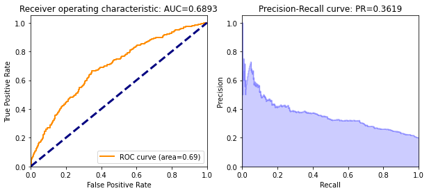

```python
ROC_AUC(gbm_test, test_hex, 'loan_default')
```

Our AUC function works well as well, demonstrating an AUC of 0.69 for the sample dataset.

## Creating our initial GBM model with the full-dataset

Now, we use the full train and test data to build a full model using all the features to build our initial model. We use default settings for all parameters, except:

- minimum rows = 100
- nfolds = 10
- ntrees = 100

```python
target = 'loan_default'
train_hex = h2o.H2OFrame(train)
test_hex = h2o.H2OFrame(test)
```

```
Parse progress: |█████████████████████████████████████████████████████████| 100%
Parse progress: |█████████████████████████████████████████████████████████| 100%
```

```python
gbm_model1 = H2OGradientBoostingEstimator(
        model_id = 'gbm_model1',
        learn_rate = 0.1,
        ntrees = 100,
        nfolds=10,
        max_depth = 5,
        min_rows=100,
        seed=257)
gbm_model1.train(predictors,target,training_frame=train_hex)
```

```
gbm Model Build progress: |███████████████████████████████████████████████| 100%
```

```python
createGains(gbm_model1, test_hex, 'loan_default')
```

```
gbm prediction progress: |████████████████████████████████████████████████| 100%
```

| decile | count | actual | non_actual | cum_count | cum_actual | cum_non_actual | percent_cum_actual | percent_cum_non_actual | if_random | lift | K_S | gain |
| --- | --- | --- | --- | --- | --- | --- | --- | --- | --- | --- | --- | --- |
| 0 | 1600 | 646 | 954 | 1600 | 646 | 954 | 0.21 | 0.07 | 310.0 | 2.08 | 14.0 | 40.38 |
| 1 | 1600 | 510 | 1090 | 3200 | 1156 | 2044 | 0.37 | 0.16 | 620.0 | 1.86 | 21.0 | 36.12 |
| 2 | 1600 | 407 | 1193 | 4800 | 1563 | 3237 | 0.50 | 0.25 | 930.0 | 1.68 | 25.0 | 32.56 |
| 3 | 1600 | 360 | 1240 | 6400 | 1923 | 4477 | 0.62 | 0.35 | 1240.0 | 1.55 | 27.0 | 30.05 |
| 4 | 1600 | 303 | 1297 | 8000 | 2226 | 5774 | 0.72 | 0.45 | 1550.0 | 1.44 | 27.0 | 27.82 |
| 5 | 1600 | 267 | 1333 | 9600 | 2493 | 7107 | 0.80 | 0.55 | 1860.0 | 1.34 | 25.0 | 25.97 |
| 6 | 1600 | 218 | 1382 | 11200 | 2711 | 8489 | 0.87 | 0.66 | 2170.0 | 1.25 | 21.0 | 24.21 |
| 7 | 1600 | 183 | 1417 | 12800 | 2894 | 9906 | 0.93 | 0.77 | 2480.0 | 1.17 | 16.0 | 22.61 |
| 8 | 1600 | 142 | 1458 | 14400 | 3036 | 11364 | 0.98 | 0.88 | 2790.0 | 1.09 | 10.0 | 21.08 |
| 9 | 1600 | 64 | 1536 | 16000 | 3100 | 12900 | 1.00 | 1.00 | 3100.0 | 1.00 | 0.0 | 19.38 |

```
gbm prediction progress: |████████████████████████████████████████████████| 100%

   * ROC curve: The ROC curve plots the true positive rate vs. the false rositive sate

	  * The area under the curve (AUC): A value between 0.5 (random) and 1.0 (perfect), measuring the prediction accuracy

   * Recall (R) = The number of true positives / (the number of true positives + the number of false negatives)
```

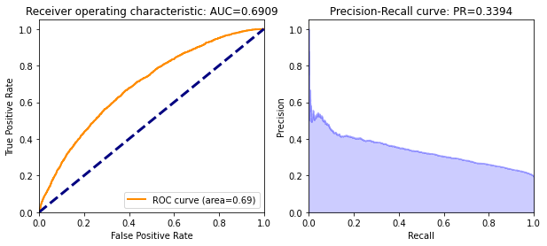

```python
ROC_AUC(gbm_model1, test_hex, 'loan_default')
```

Using the full dataset has maintained the AUC at 0.69 while precision-recall has dropped slightly

## Reducing number of features in the model

Now that we have a base initial model, we attempt to build a second model using only the important variables identified in model1. Let us see if this improves performance.

```python
ignore_col = gbm_model1._model_json['output']['variable_importances'].as_data_frame().tail(6)['variable'].to_list()
#ignore_col
preds2 = predictors.copy()
for col in ignore_col:
    preds2.remove(col)
```

```python
gbm_model2 = H2OGradientBoostingEstimator(
        model_id = 'gbm_model2',
        learn_rate = 0.1,
        ntrees = 100,
        nfolds=10,
        max_depth = 5,
        min_rows=100,
        seed=257)
gbm_model2.train(preds2,target,training_frame=train_hex)
```

```
gbm Model Build progress: |███████████████████████████████████████████████| 100%
```

```python
createGains(gbm_model2, test_hex, 'loan_default')
```

```
gbm prediction progress: |████████████████████████████████████████████████| 100%
```

| decile | count | actual | non_actual | cum_count | cum_actual | cum_non_actual | percent_cum_actual | percent_cum_non_actual | if_random | lift | K_S | gain |
| --- | --- | --- | --- | --- | --- | --- | --- | --- | --- | --- | --- | --- |
| 0 | 1600 | 640 | 960 | 1600 | 640 | 960 | 0.21 | 0.07 | 310.0 | 2.06 | 14.0 | 40.00 |
| 1 | 1600 | 509 | 1091 | 3200 | 1149 | 2051 | 0.37 | 0.16 | 620.0 | 1.85 | 21.0 | 35.91 |
| 2 | 1600 | 427 | 1173 | 4800 | 1576 | 3224 | 0.51 | 0.25 | 930.0 | 1.69 | 26.0 | 32.83 |
| 3 | 1600 | 346 | 1254 | 6400 | 1922 | 4478 | 0.62 | 0.35 | 1240.0 | 1.55 | 27.0 | 30.03 |
| 4 | 1600 | 323 | 1277 | 8000 | 2245 | 5755 | 0.72 | 0.45 | 1550.0 | 1.45 | 27.0 | 28.06 |
| 5 | 1600 | 249 | 1351 | 9600 | 2494 | 7106 | 0.80 | 0.55 | 1860.0 | 1.34 | 25.0 | 25.98 |
| 6 | 1600 | 208 | 1392 | 11200 | 2702 | 8498 | 0.87 | 0.66 | 2170.0 | 1.25 | 21.0 | 24.12 |
| 7 | 1600 | 193 | 1407 | 12800 | 2895 | 9905 | 0.93 | 0.77 | 2480.0 | 1.17 | 16.0 | 22.62 |
| 8 | 1600 | 149 | 1451 | 14400 | 3044 | 11356 | 0.98 | 0.88 | 2790.0 | 1.09 | 10.0 | 21.14 |
| 9 | 1600 | 56 | 1544 | 16000 | 3100 | 12900 | 1.00 | 1.00 | 3100.0 | 1.00 | 0.0 | 19.38 |

```
gbm prediction progress: |████████████████████████████████████████████████| 100%

   * ROC curve: The ROC curve plots the true positive rate vs. the false rositive sate

	  * The area under the curve (AUC): A value between 0.5 (random) and 1.0 (perfect), measuring the prediction accuracy

   * Recall (R) = The number of true positives / (the number of true positives + the number of false negatives)
```

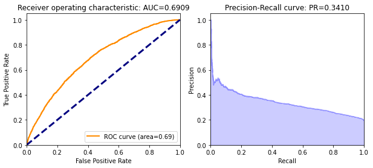

```python
ROC_AUC(gbm_model2, test_hex, 'loan_default')
```

However, AUC and precision curve areas are more or less unaffected.

## Using GridSearch for Hyper Parameter Tuning

Since using full predictors seems to have a better effect, lets use all features to tune hyperparameters. We will use h2o package's gridsearch algorithm to run the algorithm through a series of models covering different values for ntrees, max_depth and learning rate. Each of these affect the number of trees the algorithm builds, the maximum depth for each tree and the minimum change in gradient descent search during the analysis.

```python
hyper_parameters = {
        'learn_rate' : [0.001, 0.005, 0.001],
        'ntrees' : [100, 1000, 5000],
        'max_depth' : [2, 3, 4]
}
```

```python
target = 'loan_default'
train_grid = train.sample(frac=0.4, random_state=1)
test_grid = test.sample(frac=0.4, random_state=1)
train_hex = h2o.H2OFrame(train_grid)
test_hex = h2o.H2OFrame(test_grid)
```

```
Parse progress: |█████████████████████████████████████████████████████████| 100%
Parse progress: |█████████████████████████████████████████████████████████| 100%
```

```python
from h2o.grid.grid_search import H2OGridSearch

gbm_params1 = H2OGridSearch(model = H2OGradientBoostingEstimator,
                          grid_id = 'gbm_params1',
                          hyper_params = hyper_parameters)
```

```python
%%capture [--no-stderr]

gbm_params1.train(x = predictors, y = target, training_frame= train_hex, validation_frame= test_hex, nfolds = 10)
```

```python
gbm_grid1_perf = gbm_params1.get_grid(sort_by='r2', decreasing=True)
gbm_grid1_perf
```

```
     learn_rate max_depth ntrees             model_ids                    r2
0         0.005         2   5000  gbm_params1_model_20   0.06782350934699655
1         0.005         4   1000  gbm_params1_model_17   0.06624417134018967
2         0.005         3   5000  gbm_params1_model_23   0.06605599974729537
3         0.001         4   5000  gbm_params1_model_25   0.06559743829570042
4         0.001         3   5000  gbm_params1_model_22   0.06275231159177497
5         0.005         3   1000  gbm_params1_model_14  0.062320531579991956
6         0.005         4   5000  gbm_params1_model_26  0.060003731073094646
7         0.001         2   5000  gbm_params1_model_19   0.05534359530221644
8         0.005         2   1000  gbm_params1_model_11   0.05519401729988527
9         0.001         4   1000  gbm_params1_model_16   0.03919652020987929
10        0.001         3   1000  gbm_params1_model_13   0.03297296887958345
11        0.005         4    100   gbm_params1_model_8   0.02591789444426329
12        0.001         2   1000  gbm_params1_model_10      0.02533124711946
13        0.005         3    100   gbm_params1_model_5  0.021648077150751566
14        0.005         2    100   gbm_params1_model_2   0.01586026911075067
15        0.001         4    100   gbm_params1_model_7  0.007042075958583305
16        0.001         3    100   gbm_params1_model_4  0.006092249041095288
17        0.001         2    100   gbm_params1_model_1  0.004159726260945962
```

```
gbm prediction progress: |████████████████████████████████████████████████| 100%

   * ROC curve: The ROC curve plots the true positive rate vs. the false rositive sate

	  * The area under the curve (AUC): A value between 0.5 (random) and 1.0 (perfect), measuring the prediction accuracy

   * Recall (R) = The number of true positives / (the number of true positives + the number of false negatives)
```

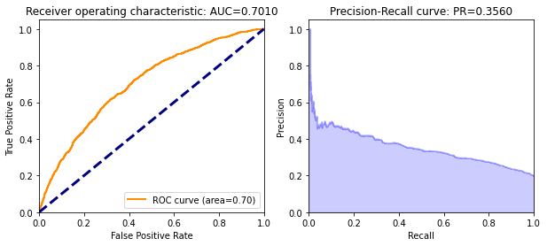

```python
ROC_AUC(gbm_grid1_perf.models[0], test_hex, 'loan_default')
```

With these hyperparameter settings, the AUC and precision have both marginally improved!

```python
createGains(gbm_grid1_perf.models[0], test_hex, 'loan_default')
```

```
gbm prediction progress: |████████████████████████████████████████████████| 100%
```

[output not shown]

While the model has provided similar results to the base model we built, we will use the parameters identified here while building models with three different conditions:

1. Best model with original, full dataset
2. Best model with undersampled dataset
3. Best model with oversampled dataset

Based on the gridsearch, we will use the following hyper parameters: max_depth = 2, min_rows = 100, learning rate = 0.005, ntrees = 5000

## Using the best model with full, orginal dataset

In this section, we use the best parameters with the full, original dataset.

```python
target = 'loan_default'
train_hex = h2o.H2OFrame(train)
test_hex = h2o.H2OFrame(test)
```

```
Parse progress: |█████████████████████████████████████████████████████████| 100%
Parse progress: |█████████████████████████████████████████████████████████| 100%
```

```python
gbm_model4 = H2OGradientBoostingEstimator(
        model_id = 'gbm_model4',
        learn_rate = 0.005,
        ntrees = 5000,
        nfolds=10,
        max_depth = 2,
        min_rows = 100,
        #balance_classes = True,
        seed=257)
gbm_model4.train(predictors, target, training_frame=train_hex)
```

```
gbm Model Build progress: |███████████████████████████████████████████████| 100%
```

```python
createGains(gbm_model4, test_hex, 'loan_default')
```

```
gbm prediction progress: |████████████████████████████████████████████████| 100%
```

| decile | count | actual | non_actual | cum_count | cum_actual | cum_non_actual | percent_cum_actual | percent_cum_non_actual | if_random | lift | K_S | gain |
| --- | --- | --- | --- | --- | --- | --- | --- | --- | --- | --- | --- | --- |
| 0 | 1600 | 661 | 939 | 1600 | 661 | 939 | 0.21 | 0.07 | 310.0 | 2.13 | 14.0 | 41.31 |
| 1 | 1600 | 503 | 1097 | 3200 | 1164 | 2036 | 0.38 | 0.16 | 620.0 | 1.88 | 22.0 | 36.38 |
| 2 | 1600 | 394 | 1206 | 4800 | 1558 | 3242 | 0.50 | 0.25 | 930.0 | 1.68 | 25.0 | 32.46 |
| 3 | 1600 | 348 | 1252 | 6400 | 1906 | 4494 | 0.61 | 0.35 | 1240.0 | 1.54 | 26.0 | 29.78 |
| 4 | 1600 | 308 | 1292 | 8000 | 2214 | 5786 | 0.71 | 0.45 | 1550.0 | 1.43 | 26.0 | 27.68 |
| 5 | 1600 | 279 | 1321 | 9600 | 2493 | 7107 | 0.80 | 0.55 | 1860.0 | 1.34 | 25.0 | 25.97 |
| 6 | 1600 | 257 | 1343 | 11200 | 2750 | 8450 | 0.89 | 0.66 | 2170.0 | 1.27 | 23.0 | 24.55 |
| 7 | 1600 | 136 | 1464 | 12800 | 2886 | 9914 | 0.93 | 0.77 | 2480.0 | 1.16 | 16.0 | 22.55 |
| 8 | 1600 | 138 | 1462 | 14400 | 3024 | 11376 | 0.98 | 0.88 | 2790.0 | 1.08 | 10.0 | 21.00 |
| 9 | 1600 | 76 | 1524 | 16000 | 3100 | 12900 | 1.00 | 1.00 | 3100.0 | 1.00 | 0.0 | 19.38 |

Using the full dataset, marginally improved lift to 2.13!

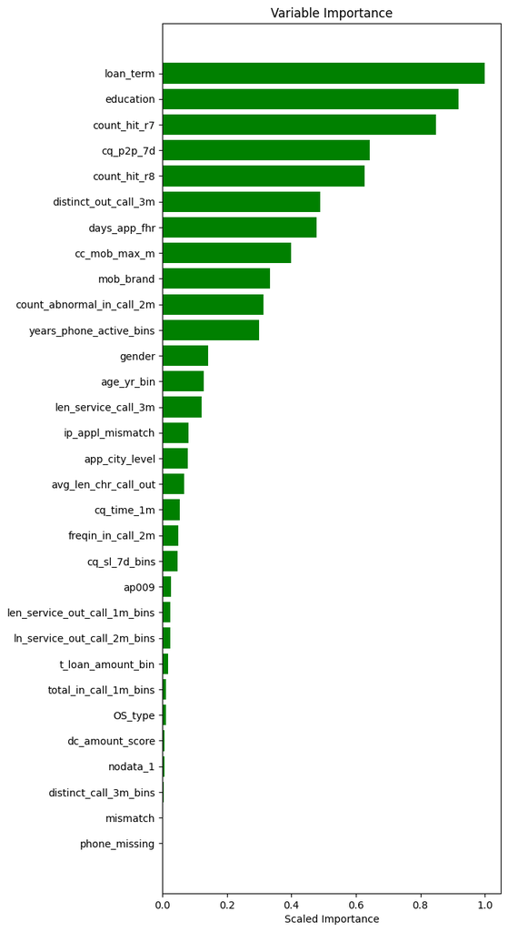

```python
VarImp(gbm_model4)
```

As expected the most important paramaters in both GBM and RFM are the same!

## Solving for imbalance to improve results

### Best model with an undersampled dataset

Now, we attempt to train the model using an undersampled dataset, we use a ratio of 1:3.

```python
target = 'loan_default'
train2 = train.copy()
test2 = test.copy()
#train_hex = h2o.H2OFrame(train)
#test_hex = h2o.H2OFrame(test)

#Using oversampling strategy
y = train2[target].astype('category')
X = train2.drop(target,axis=1)
y1_cnt = train2[target].sum()
N = 3
y0_cnt = y1_cnt * N

from imblearn.datasets import make_imbalance
X_rs, y_rs = make_imbalance(X, y, sampling_strategy={1:y1_cnt , 0:  y0_cnt}, random_state=0)
X_rs = pd.DataFrame(X_rs)
y_rs = pd.DataFrame(y_rs)
smpl = pd.concat([X_rs,y_rs], axis = 1)
train2_hex = h2o.H2OFrame(smpl)

test2['loan_default'] = test2['loan_default'].astype('category')
test2_hex = h2o.H2OFrame(test2)
```

```
Parse progress: |█████████████████████████████████████████████████████████| 100%
Parse progress: |█████████████████████████████████████████████████████████| 100%
```

```python
gbm_model5 = H2OGradientBoostingEstimator(
        model_id = 'gbm_model5',
        learn_rate = 0.005,
        learn_rate_annealing = 0.99,
        ntrees = 5000,
        nfolds=10,
        max_depth = 2,
        stopping_rounds = 5,
        #stopping_metric = "AUC",
        seed=257)
gbm_model5.train(predictors, target, training_frame=train2_hex)
```

```
gbm Model Build progress: |███████████████████████████████████████████████| 100%
```

```python
createGains(gbm_model5, test2_hex, 'loan_default')
```

```
gbm prediction progress: |████████████████████████████████████████████████| 100%
```

| decile | count | actual | non_actual | cum_count | cum_actual | cum_non_actual | percent_cum_actual | percent_cum_non_actual | if_random | lift | K_S | gain |
| --- | --- | --- | --- | --- | --- | --- | --- | --- | --- | --- | --- | --- |
| 0 | 1600 | 430 | 1170 | 1600 | 430 | 1170 | 0.14 | 0.09 | 310.0 | 1.39 | 5.0 | 26.88 |
| 1 | 1600 | 425 | 1175 | 3200 | 855 | 2345 | 0.28 | 0.18 | 620.0 | 1.38 | 10.0 | 26.72 |
| 2 | 1600 | 394 | 1206 | 4800 | 1249 | 3551 | 0.40 | 0.28 | 930.0 | 1.34 | 12.0 | 26.02 |
| 3 | 1600 | 247 | 1353 | 6400 | 1496 | 4904 | 0.48 | 0.38 | 1240.0 | 1.21 | 10.0 | 23.38 |
| 4 | 1600 | 287 | 1313 | 8000 | 1783 | 6217 | 0.58 | 0.48 | 1550.0 | 1.15 | 10.0 | 22.29 |
| 5 | 1600 | 293 | 1307 | 9600 | 2076 | 7524 | 0.67 | 0.58 | 1860.0 | 1.12 | 9.0 | 21.62 |
| 6 | 1600 | 289 | 1311 | 11200 | 2365 | 8835 | 0.76 | 0.68 | 2170.0 | 1.09 | 8.0 | 21.12 |
| 7 | 1600 | 300 | 1300 | 12800 | 2665 | 10135 | 0.86 | 0.79 | 2480.0 | 1.07 | 7.0 | 20.82 |
| 8 | 1600 | 316 | 1284 | 14400 | 2981 | 11419 | 0.96 | 0.89 | 2790.0 | 1.07 | 7.0 | 20.70 |
| 9 | 1600 | 119 | 1481 | 16000 | 3100 | 12900 | 1.00 | 1.00 | 3100.0 | 1.00 | 0.0 | 19.38 |

Contrary to RFM, undersampling has reduced the lift significantly. This could be because for this particular dataset, the minority lablel has a salience of nearly 20% originally.

### Best model with oversampled dataset

We used imblearn's randomoversampler function to build an oversampled dataset to train the model.

```python
##Oversampling techniques

from imblearn.over_sampling import RandomOverSampler
# define oversampling strategy
oversample = RandomOverSampler(sampling_strategy='minority')
target = 'loan_default'
train3 = train.copy()
test3 = test.copy()

X3 = train3.drop(columns = target)
y3 = train3[target].astype('category')
X_over, y_over = oversample.fit_resample(X3, y3)
train3_over = pd.concat([X_over, y_over], axis = 1)
train3_hex = h2o.H2OFrame(train3_over)

test3['loan_default'] = test3['loan_default'].astype('category')
test3_hex = h2o.H2OFrame(test3)
```

```
Parse progress: |█████████████████████████████████████████████████████████| 100%
Parse progress: |█████████████████████████████████████████████████████████| 100%
```

```python
gbm_model6 = H2OGradientBoostingEstimator(
        model_id = 'gbm_model6',
        learn_rate = 0.005,
        learn_rate_annealing = 0.99,
        ntrees = 5000,
        nfolds=10,
        max_depth = 2,
        stopping_rounds = 5,
        #stopping_metric = "AUC",
        seed=257)
gbm_model6.train(predictors, target, training_frame=train3_hex)
```

```
gbm Model Build progress: |███████████████████████████████████████████████| 100%
```

```python
createGains(gbm_model6, test3_hex, 'loan_default')
```

```
gbm prediction progress: |████████████████████████████████████████████████| 100%
```

| decile | count | actual | non_actual | cum_count | cum_actual | cum_non_actual | percent_cum_actual | percent_cum_non_actual | if_random | lift | K_S | gain |
| --- | --- | --- | --- | --- | --- | --- | --- | --- | --- | --- | --- | --- |
| 0 | 1600 | 497 | 1103 | 1600 | 497 | 1103 | 0.16 | 0.09 | 310.0 | 1.60 | 7.0 | 31.06 |
| 1 | 1600 | 409 | 1191 | 3200 | 906 | 2294 | 0.29 | 0.18 | 620.0 | 1.46 | 11.0 | 28.31 |
| 2 | 1600 | 337 | 1263 | 4800 | 1243 | 3557 | 0.40 | 0.28 | 930.0 | 1.34 | 12.0 | 25.90 |
| 3 | 1600 | 380 | 1220 | 6400 | 1623 | 4777 | 0.52 | 0.37 | 1240.0 | 1.31 | 15.0 | 25.36 |
| 4 | 1600 | 328 | 1272 | 8000 | 1951 | 6049 | 0.63 | 0.47 | 1550.0 | 1.26 | 16.0 | 24.39 |
| 5 | 1600 | 270 | 1330 | 9600 | 2221 | 7379 | 0.72 | 0.57 | 1860.0 | 1.19 | 15.0 | 23.14 |
| 6 | 1600 | 250 | 1350 | 11200 | 2471 | 8729 | 0.80 | 0.68 | 2170.0 | 1.14 | 12.0 | 22.06 |
| 7 | 1600 | 250 | 1350 | 12800 | 2721 | 10079 | 0.88 | 0.78 | 2480.0 | 1.10 | 10.0 | 21.26 |
| 8 | 1600 | 261 | 1339 | 14400 | 2982 | 11418 | 0.96 | 0.89 | 2790.0 | 1.07 | 7.0 | 20.71 |
| 9 | 1600 | 118 | 1482 | 16000 | 3100 | 12900 | 1.00 | 1.00 | 3100.0 | 1.00 | 0.0 | 19.38 |

While performing better than undersampling, the model still performs worse than using the original dataset.

## Using Deep Learning to build a predictor

In this section, we use the keras package from tensor flow to build a sequential deep-learning model to predict loan default.

Before we train the model, we prepare the data through the following steps:

1. convert all categorical variables into numerical encoding using scikit learn's labelencoder
2. seperate independent variables and target variables into two dataframes
3. normalize and convert both dataframes into numpy arrays
4. replace all nan, inf values to 0

```python
%%capture [--no-stderr]

train_tl = train.copy()
test_tl = test.copy()

#Ordinal levels needed for: ['v_rel', 'v_type', 'p_location', 'p_type', 'loc_z', 'loc_b', 'loc_n', 'open_24']
ord_factors = ['age_yr_bin', 't_loan_amount_bin', 'distinct_call_3m_bins', 'years_phone_active_bins', 'years_phone_active_bins', 'total_in_call_1m_bins', 'len_service_out_call_1m_bins',
              'cq_sl_7d_bins', 'len_service_out_call_2m_bins', 'mob_brand', 'education', 'gender', 'loan_term', 'OS_type', 'app_city_level', 'ip_appl_mismatch', 'ap009']

from sklearn import preprocessing
le = preprocessing.LabelEncoder()

for col in ord_factors:
    le.fit(train_tl[col])
    train_tl[col] = le.transform(train_tl[col])
    le.fit(test_tl[col])
    test_tl[col] = le.transform(test_tl[col])

train_tl_target = train_tl.pop(target)
test_tl_target = test_tl.pop(target)

from sklearn.preprocessing import StandardScaler
scaler = StandardScaler()

train_tl = scaler.fit_transform(train_tl)
test_tl = scaler.fit_transform(test_tl)
train_tl_target = train_tl_target.to_numpy(dtype = float)
test_tl_target = test_tl_target.to_numpy(dtype = float)
```

```python
from keras.models import Sequential
from keras.layers import Dense, Activation
import tensorflow as tf
```

```python
64000*45
train_tl = np.nan_to_num(train_tl, nan = 0, posinf=0, neginf=0)
test_tl = np.nan_to_num(test_tl, nan = 0, posinf=0, neginf=0)
```

We build a sequential model with 6 layers as follows:

- Input layer: dense layer with 15 nodes
- Activation Layer
- Dense Layer with 2 nodes
- Activation Layer
- Dense layer with 1 node
- Activation Layer

We also attempted models with 8 and 10 layers, and nodes ranging from 2 to 45. We also varied the number of epochs between 50 and 1000.

```python
#from keras.utils.visualize_util import plot
dl_mod = Sequential()
dl_mod.add(Dense(15, input_dim = 45))
dl_mod.add(Activation(activation='sigmoid'))
#dl_mod.add(Dense(10))
#dl_mod.add(Activation(activation='sigmoid'))
dl_mod.add(Dense(2))
dl_mod.add(Activation(activation='sigmoid'))
dl_mod.add(Dense(1))
dl_mod.add(Activation(activation='sigmoid'))

dl_mod.compile(optimizer='Adam', loss='BinaryCrossentropy', metrics=['BinaryCrossentropy', 'AUC'])
dl_mod.fit(train_tl, train_tl_target, epochs=100, verbose=0)

score = dl_mod.evaluate(train_tl, train_tl_target, verbose=0)
print(dl_mod.metrics_names, score)
```

```
['loss', 'binary_crossentropy', 'auc'] [0.4453780949115753, 0.4453780949115753, 0.7125332355499268]
```

```python
dl_mod.summary()
```

```
Model: "sequential_40"
_________________________________________________________________
Layer (type)                 Output Shape              Param #
=================================================================
dense_102 (Dense)            (None, 15)                690
_________________________________________________________________
activation_97 (Activation)   (None, 15)                0
_________________________________________________________________
dense_103 (Dense)            (None, 2)                 32
_________________________________________________________________
activation_98 (Activation)   (None, 2)                 0
_________________________________________________________________
dense_104 (Dense)            (None, 1)                 3
_________________________________________________________________
activation_99 (Activation)   (None, 1)                 0
=================================================================
Total params: 725
Trainable params: 725
Non-trainable params: 0
_________________________________________________________________
```

```python
dl_preds = dl_mod.predict(test_tl)
```

```python
createGains_dl(dl_preds, test, 'loan_default')
```

| decile | count | actual | non_actual | cum_count | cum_actual | cum_non_actual | percent_cum_actual | percent_cum_non_actual | if_random | lift | K_S | gain |
| --- | --- | --- | --- | --- | --- | --- | --- | --- | --- | --- | --- | --- |
| 0 | 1600 | 637 | 963 | 1600 | 637 | 963 | 0.21 | 0.07 | 310.0 | 2.05 | 14.0 | 39.81 |
| 1 | 1600 | 485 | 1115 | 3200 | 1122 | 2078 | 0.36 | 0.16 | 620.0 | 1.81 | 20.0 | 35.06 |
| 2 | 1600 | 411 | 1189 | 4800 | 1533 | 3267 | 0.49 | 0.25 | 930.0 | 1.65 | 24.0 | 31.94 |
| 3 | 1600 | 359 | 1241 | 6400 | 1892 | 4508 | 0.61 | 0.35 | 1240.0 | 1.53 | 26.0 | 29.56 |
| 4 | 1600 | 305 | 1295 | 8000 | 2197 | 5803 | 0.71 | 0.45 | 1550.0 | 1.42 | 26.0 | 27.46 |
| 5 | 1600 | 261 | 1339 | 9600 | 2458 | 7142 | 0.79 | 0.55 | 1860.0 | 1.32 | 24.0 | 25.60 |
| 6 | 1600 | 221 | 1379 | 11200 | 2679 | 8521 | 0.86 | 0.66 | 2170.0 | 1.23 | 20.0 | 23.92 |
| 7 | 1600 | 180 | 1420 | 12800 | 2859 | 9941 | 0.92 | 0.77 | 2480.0 | 1.15 | 15.0 | 22.34 |
| 8 | 1600 | 156 | 1444 | 14400 | 3015 | 11385 | 0.97 | 0.88 | 2790.0 | 1.08 | 9.0 | 20.94 |
| 9 | 1600 | 85 | 1515 | 16000 | 3100 | 12900 | 1.00 | 1.00 | 3100.0 | 1.00 | 0.0 | 19.38 |